# Spam Filtering with Machine Learning using the Naive Bayes Algorithm

Tue 14 November 2017

In this notebook we will explore a [UCI SMS Spam Dataset](https://www.kaggle.com/uciml/sms-spam-collection-dataset/data). Using the Naive Bayes algorithm we'll classify messages as spam or not spam. It's a tasty problem to solve considering not spam is often referred to as ham.

**Results Summary** We clean our data, learn Bayes Theorem, learn Vectorization, how to use scikit learn to create predictive models and how to interpret our results.  
Our model achieved 91% accuracy in classifying spam.

**Limitations** We look at only Count Vectorization and the Gaussian Naive Bayes model. We explore only one dataset

**Click the button below if you want to see the code**

```python
from IPython.display import HTML
HTML('''
''')
```

# Data Objective: Learn how to use Naive Bayes Algorithm to classify email spam

This is my first notebook on Machine Learning. So it will be a reference for me later as well as exploratory learning into the topic.

# Data Cleaning

We're only using the one dataset today so we start with data cleaning.  
Below we load our libraries and show our setup.

```python
# Data Processing
import pandas as pd
import numpy as np
import ipy_table as tbl # for tables
import os
os.chdir('C:\\Users\\JWC\\Google Drive\\Home\\Datastuff\\Udacity\\Section 7 - Machine Learning\\Lesson 2 - Naive Bayes')
import re

# Visuals
import matplotlib.pyplot as plt
import seaborn as sns
# Using easy highcharts for interactive charts
import ezhc as hc
%matplotlib inline
import scikitplot as skplt
from IPython.display import Image
from IPython.core.display import HTML

# Machine learning
from sklearn.naive_bayes import GaussianNB
from sklearn import metrics
from sklearn.feature_extraction.text import TfidfVectorizer, CountVectorizer
from sklearn.feature_selection import SelectPercentile, f_classif
from sklearn.model_selection import train_test_split
from sklearn.metrics import confusion_matrix, classification_report, roc_auc_score

#Tells Jupyter to print results of any variable on a new line so tables will look good
from IPython.core.interactiveshell import InteractiveShell
InteractiveShell.ast_node_interactivity = "all"

# Check what was loaded
%load_ext version_information
%version_information pandas, ipython, jupyter, ezhc, sklearn
```

```
Open console to check js libs were loaded in page
```

| Software | Version |
| --- | --- |
| Python | 3.6.1 64bit [MSC v.1900 64 bit (AMD64)] |
| IPython | 6.1.0 |
| OS | Windows 10 10.0.16299 SP0 |
| pandas | 0.20.3 |
| ipython | 6.1.0 |
| jupyter | 1.0.0 |
| ezhc | 0.6.7 |
| sklearn | 0.18.1 |
| Mon Dec 11 17:13:14 2017 AUS Eastern Daylight Time |  |

```python
os.getcwd()
```

```
'C:\\Users\\JWC\\Google Drive\\Home\\Datastuff\\Udacity\\Section 7 - Machine Learning\\Lesson 2 - Naive Bayes'
```

```python
df = pd.read_csv('spam.csv', encoding='latin-1')
```

Check we're in the correct folder and load our dataset.

Then browse our dataset.

```python
df.head()
```

|  | v1 | v2 | Unnamed: 2 | Unnamed: 3 | Unnamed: 4 |
| --- | --- | --- | --- | --- | --- |
| 0 | ham | Go until jurong point, crazy.. Available only ... | NaN | NaN | NaN |
| 1 | ham | Ok lar... Joking wif u oni... | NaN | NaN | NaN |
| 2 | spam | Free entry in 2 a wkly comp to win FA Cup fina... | NaN | NaN | NaN |
| 3 | ham | U dun say so early hor... U c already then say... | NaN | NaN | NaN |
| 4 | ham | Nah I don't think he goes to usf, he lives aro... | NaN | NaN | NaN |

```python
df.info()
```

```
RangeIndex: 5572 entries, 0 to 5571
Data columns (total 5 columns):
v1            5572 non-null object
v2            5572 non-null object
Unnamed: 2    50 non-null object
Unnamed: 3    12 non-null object
Unnamed: 4    6 non-null object
dtypes: object(5)
memory usage: 217.7+ KB
```

- Column v1 are our labels, spam or ham (not spam).
- Column v2 are our messages.

Then there are 3 columns that are not so obvious. We see there are many null values and hardly any non-null values. We'll rename these columns since their names are a bit long.

```python
df = df.rename(columns = {'Unnamed: 2': 'u2', 'Unnamed: 3': 'u3', 'Unnamed: 4':'u4'})
```

```python
df.head()
```

|  | v1 | v2 | u2 | u3 | u4 |
| --- | --- | --- | --- | --- | --- |
| 0 | ham | Go until jurong point, crazy.. Available only ... | NaN | NaN | NaN |
| 1 | ham | Ok lar... Joking wif u oni... | NaN | NaN | NaN |
| 2 | spam | Free entry in 2 a wkly comp to win FA Cup fina... | NaN | NaN | NaN |
| 3 | ham | U dun say so early hor... U c already then say... | NaN | NaN | NaN |
| 4 | ham | Nah I don't think he goes to usf, he lives aro... | NaN | NaN | NaN |

We built a function to return unique types and how many of each type in each pandas series or dataframe. Here we find our 'unknown' columns have strings amongst their null values. Where null values will show up as float.

```python
# Finds all unique types with count in a dataframe per column
def findtypes(df,series=False):
    d = {}
    if series == False:
        for item in df:
            clas = re.findall('\'(.*?)\'',(str(pd.Series(list(map(type,df[item]))).unique())))
            vals = list(pd.Series(list(map(type,df[item]))).value_counts())
            d[item] = ['{}: {}'.format(clas,vals) for clas,vals in zip(clas,vals)]
        return d
    else:
        clas = re.findall('\'(.*?)\'',(str(pd.Series(list(map(type,df))).unique())))
        vals = list(pd.Series(list(map(type,df))).value_counts())
        return ['{}: {}'.format(clas,vals) for clas,vals in zip(clas,vals)]

# Can use lines like these to look at odd looking cells
# df['col'][df.col.str.contains('\w').notnull()] or df['u2'][df.u2.notnull()]
# df['col'][[x==float for x in list(map(type,df.col))]]
```

```python
findtypes(df)
```

```
{'u2': ['float: 5522', 'str: 50'],
 'u3': ['float: 5560', 'str: 12'],
 'u4': ['float: 5566', 'str: 6'],
 'v1': ['str: 5572'],
 'v2': ['str: 5572']}
```

```python
df.info()
```

```
RangeIndex: 5572 entries, 0 to 5571
Data columns (total 5 columns):
v1    5572 non-null object
v2    5572 non-null object
u2    50 non-null object
u3    12 non-null object
u4    6 non-null object
dtypes: object(5)
memory usage: 217.7+ KB
```

Combined with the info() function we can see that all the floats in u2, u3 and u4 are all nulls, so we'll have a look at the strings. Below are the first 5 messages for u2, u3 and u4 in that order.

```python
df['u2'][df.u2.str.contains('\w').notnull()].head()
```

```
95                                           PO Box 5249
281     the person is definitely special for u..... B...
444     HOWU DOIN? FOUNDURSELF A JOBYET SAUSAGE?LOVE ...
671     wanted to say hi. HI!!!\" Stop? Send STOP to ...
710      this wont even start........ Datz confidence.."
Name: u2, dtype: object
```

```python
df['u3'][df.u3.str.contains('\w').notnull()].head()
```

```
95                          MK17 92H. 450Ppw 16"
281                             why to miss them
899                         MK17 92H. 450Ppw 16"
1038                                          GE
2170    U NO THECD ISV.IMPORTANT TOME 4 2MORO\""
Name: u3, dtype: object
```

```python
df['u4'][df.u4.str.contains('\w').notnull()].head()
```

```
281                         just Keep-in-touch\" gdeve.."
1038                                              GNT:-)"
2255     Never comfort me with a lie\" gud ni8 and swe...
3525                  CALL 2MWEN IM BK FRMCLOUD 9! J X\""
4668      one day these two will become FREINDS FOREVER!"
Name: u4, dtype: object
```

If we inspect line 281 we see that u2, u3 and u4 are all part of the same message, likely separated because the message has commas in it. So we'll join the messages back together.

```python
df.iloc[281,:]
```

```
v1                                                  ham
v2                                  \Wen u miss someone
u2     the person is definitely special for u..... B...
u3                                     why to miss them
u4                        just Keep-in-touch\" gdeve.."
Name: 281, dtype: object
```

```python
df['msg'] = df['v2'] + df['u2'].astype(str) + df['u3'].astype(str) + df['u4'].astype(str)
```

After concatenation we check our first message (line 0). Here we see 'nannannan' has been concatenated at the end. Where nan (not a number) is the same as a null or missing value. This will create unwanted features for us later so we'll remove them.

```python
df['msg'][0]
```

```
'Go until jurong point, crazy.. Available only in bugis n great world la e buffet... Cine there got amore wat...nannannan'
```

```python
# 0 to 3 nan's at the end of our string which will we substitute with an empty string
df['msg'] = df['msg'].apply(lambda x: re.sub('(nan){0,3}$','',x))
df['msg'].head()
```

```
0    Go until jurong point, crazy.. Available only ...
1                        Ok lar... Joking wif u oni...
2    Free entry in 2 a wkly comp to win FA Cup fina...
3    U dun say so early hor... U c already then say...
4    Nah I don't think he goes to usf, he lives aro...
Name: msg, dtype: object
```

Below we compare our previous output and our new column 'msg' which has the complete message.

```python
df.iloc[281,:]
```

```
v1                                                   ham
v2                                   \Wen u miss someone
u2      the person is definitely special for u..... B...
u3                                      why to miss them
u4                         just Keep-in-touch\" gdeve.."
msg    \Wen u miss someone the person is definitely s...
Name: 281, dtype: object
```

```python
df['msg'][281]
```

```
'\\Wen u miss someone the person is definitely special for u..... But if the person is so special why to miss them just Keep-in-touch\\" gdeve.."'
```

```python
df.head()
```

|  | v1 | v2 | u2 | u3 | u4 | msg |
| --- | --- | --- | --- | --- | --- | --- |
| 0 | ham | Go until jurong point, crazy.. Available only ... | NaN | NaN | NaN | Go until jurong point, crazy.. Available only ... |
| 1 | ham | Ok lar... Joking wif u oni... | NaN | NaN | NaN | Ok lar... Joking wif u oni... |
| 2 | spam | Free entry in 2 a wkly comp to win FA Cup fina... | NaN | NaN | NaN | Free entry in 2 a wkly comp to win FA Cup fina... |
| 3 | ham | U dun say so early hor... U c already then say... | NaN | NaN | NaN | U dun say so early hor... U c already then say... |
| 4 | ham | Nah I don't think he goes to usf, he lives aro... | NaN | NaN | NaN | Nah I don't think he goes to usf, he lives aro... |

We are now only concerned with v1 and msg. Our data is now cleaned and ready for analysis.

```python
df[['v1','msg']].head()
```

|  | v1 | msg |
| --- | --- | --- |
| 0 | ham | Go until jurong point, crazy.. Available only ... |
| 1 | ham | Ok lar... Joking wif u oni... |
| 2 | spam | Free entry in 2 a wkly comp to win FA Cup fina... |
| 3 | ham | U dun say so early hor... U c already then say... |
| 4 | ham | Nah I don't think he goes to usf, he lives aro... |

```python
df[['v1','msg']].info()
```

```
RangeIndex: 5572 entries, 0 to 5571
Data columns (total 2 columns):
v1     5572 non-null object
msg    5572 non-null object
dtypes: object(2)
memory usage: 87.1+ KB
```

We look at how much spam is in this dataset and we find around 13%.

```python
cSpam = pd.DataFrame(df.v1.value_counts())
```

```python
g = hc.Highcharts()

g.chart.type = 'pie'
g.tooltip.enabled = 'False'
g.tooltip.headerFormat = '{point.key}
'
g.tooltip.pointFormat= '{point.percentage:.1f}%
 {point.y} of 7 043'
# hc.Highcharts().setOptions.lang.thousandsSep = ','

gpo = g.plotOptions.pie
gpo.dataLabels.format = '{point.name}: {point.percentage:.1f}%'
gpo.states.hover.enabled = 'False'


g.title.text = 'Spam Percentage'
g.series = hc.build.series(cSpam)

g.plot()
```

[output not shown]

We're almost ready to build our machine learning model, but first we should understand Bayes' Theorem and Vectorization.

# Bayes' Theorem

Bayes theorem is a method to calculate conditional probability.
We read $P(A|B)$ as the probability of A given B. Which means if B were to occur, what is the probability of A occuring. $$P(A|B) = \frac{P(B|A) \times P(A)}{P(B)}$$

To make sense of the formula let's go through an email spam example. Here we assign the probability of spam and not spam to be equal at 50%. Where A' represents not A, the complement of A.

**Step 1 - Prior - Find probability of our dependent variable**  
$P(A) = P(spam) = 0.5$  
$P(A') = P(not \space spam) = 0.5$

**Step 2 - Joint - Find probability of our independent variables given our two scenarios**  
For simplicity we'll assume only 3 words are used in emails: "prize", "locksmith" and "morning". We'll assign probabilities to them. We'll say emails with prize have a high chance (70% chance) of being spam.  
$P(prize|spam) = 0.7$  
$P(locksmith|spam) = 0.1$  
$P(morning|spam) = 0.2$

$P(prize|not \space spam) = 0.1$  
$P(locksmith|not \space spam) = 0.5$  
$P(morning|not \space spam) = 0.4$

We can calculate this by adding the probability of "morning prize" given it is spam and the probability of "morning prize" given it is not spam.  
$P(morning \space prize|spam) = P(morning|spam) \times P(prize|spam) = 0.2 \times 0.7 = 0.14$  
$P(morning \space prize|not \space spam) = P(morning|not \space spam) \times P(prize|not \space spam) = 0.4 \times 0.1 = 0.04$  
$P(morning \space prize) = 0.14 + 0.04 = 0.18$

## Assumptions

In a Naive Bayes model we presume that words are independent of one another, so we don't look at the order of words. This is where the algorithm's name "Naive" comes from.

# Vectorization

Next we'll learn what it means to vectorize our data. The purpose of vectorizing is to separate our features into distinct values for use later. In our explanation of Bayes Theorem above, Step 2 was vectorizing our data. Where we took each word in an email as a feature and associated a value with it.

One simple way we could vectorize our data is to look at an email and count every word that is used. In the below example we'll see how this is done.

```python
df[['v1','msg']].iloc[10:12,:]
```

|  | v1 | msg |
| --- | --- | --- |
| 10 | ham | I'm gonna be home soon and i don't want to tal... |
| 11 | spam | SIX chances to win CASH! From 100 to 20,000 po... |

We'll simplify these two lines so there are fewer words to look at.

```python
exampleData = df['msg'].iloc[10:12].apply(lambda x: x[:23])
exampleData
```

```
10    I'm gonna be home soon
11    SIX chances to win CASH
Name: msg, dtype: object
```

The simplest vectorisation would be to count each of the words. Also notice that spacing and word boundaries are removed. This function creates our feature list aka vocabulary.

```python
vecCount = CountVectorizer()
vecCount.fit(exampleData)
```

```
CountVectorizer(analyzer='word', binary=False, decode_error='strict',
        dtype=, encoding='utf-8', input='content',
        lowercase=True, max_df=1.0, max_features=None, min_df=1,
        ngram_range=(1, 1), preprocessor=None, stop_words=None,
        strip_accents=None, token_pattern='(?u)\\b\\w\\w+\\b',
        tokenizer=None, vocabulary=None)
```

These are the features we're returned with. Notice "I'm" was removed, there are no spaces and all words are now lower case.

```python
exampleFeatures = vecCount.get_feature_names()
exampleFeatures
```

```
['be', 'cash', 'chances', 'gonna', 'home', 'six', 'soon', 'to', 'win']
```

In order for our model to use this data we need to transform it into a document-term matrix (dense matrix). This is simply a table of values for each word. The sparse matrix is an intermediary step.

```python
exampleSPM = vecCount.transform(exampleData)
exampleSPM
```

```
<2x9 sparse matrix of type ''
	with 9 stored elements in Compressed Sparse Row format>
```

The sparse matrix lacks full detail. It stores only non-zero values.

```python
print(exampleSPM)
```

```
  (0, 0)	1
  (0, 3)	1
  (0, 4)	1
  (0, 6)	1
  (1, 1)	1
  (1, 2)	1
  (1, 5)	1
  (1, 7)	1
  (1, 8)	1
```

Here the document-term matrix stores zero and non-zero values, once we add labels it's much easier to understand. We see the counts for each word in both example messages.

```python
exampleDTM = exampleSPM.toarray()
exampleDTM
```

```
array([[1, 0, 0, 1, 1, 0, 1, 0, 0],
       [0, 1, 1, 0, 0, 1, 0, 1, 1]], dtype=int64)
```

```python
pd.DataFrame(exampleDTM,columns=exampleFeatures,index=['ham example','spam example'])
```

|  | be | cash | chances | gonna | home | six | soon | to | win |
| --- | --- | --- | --- | --- | --- | --- | --- | --- | --- |
| ham example | 1 | 0 | 0 | 1 | 1 | 0 | 1 | 0 | 0 |
| spam example | 0 | 1 | 1 | 0 | 0 | 1 | 0 | 1 | 1 |

Now we understand the steps that will follow.  
Here is where we are up to in the Data Analysis process.

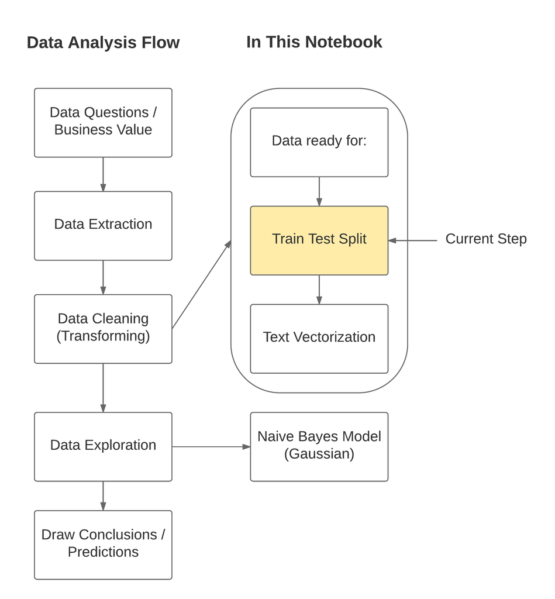

```python
Image('NBml.png',width=550)
```

We randomly divide our data, 25% for testing and 75% for training. We do this so that our training model has never seen the test data. This simulates the real world and lowers our chance of overfitting. We use random_state=1 so we can reproduce our results.

```python
# Allocate 25% of the data for testing
features_train, features_test, labels_train, labels_test = train_test_split(df.msg, df.v1, test_size=0.25, random_state=1)
```

We create a document term matrix for our training features and testing features. We use .fit_transform for the training dataset as we want to use features from the training dataset as our features/vocabulary.

```python
features_train_dtm = vecCount.fit_transform(features_train).toarray()
features_test_dtm = vecCount.transform(features_test).toarray()
```

Checking the shape of our transformed training and test data. We have the same number of columns which is what we need.

```python
print('features train shape (row,col): ',features_train_dtm.shape)
print('features test shape (row,col): ',features_test_dtm.shape)
```

```
features train shape (row,col):  (4179, 7576)
features test shape (row,col):  (1393, 7576)
```

# Modelling with Naive Bayes

We will use a Gaussian Naive Bayes Algorithm to build our prediction model. It is a model that can outperform other models when we don't have a lot of training data, it also runs quickly so we don't need a lot of time to train it.

Real world examples of where Naive Bayes models are used:

- Marking email as spam or not spam
- Classifying articles. E.g. Sports, technology, lifestyle
- Sentiment analysis. E.g. Is this product review positive or negative?

Next Steps

1. Train the model with our features (in dtm form) and our labels
2. Create predictions
3. Assess our model

```python
model = GaussianNB()
model.fit(features_train_dtm,labels_train)
```

```
GaussianNB(priors=None)
```

```python
predictions = model.predict(features_test_dtm)
```

```python
acc = metrics.accuracy_score(labels_test, predictions);
print('Model Accuracy: {} ≈ {}%'.format(acc,int(acc*100)))
```

```
Model Accuracy: 0.9102656137832017 ≈ 91%
```

Using a Count Vectorizer and Guassian Naive Bayes model we achieved 91% accuracy. Not bad for a first try. Accuracy is good metric for symmetrical data, that is, if we had an equal amount of spam and ham in our dataset.

Better metrics are the F1-Score and ROC AUC. For more details see Appendix 1.

First we'll look at our confusion matrix.

```python
# Typical Confusion Matrix
tcm = [['Actual (row) / Predicted (col)','Negative', 'Survived'],
      ['Negative','True Negative','False Positive'],
      ['Positive','False Negative','True Positive']]
tbl.make_table(tcm)
tbl.set_global_style(align='center')
tbl.set_row_style(0, bold=True)
tbl.set_column_style(0, bold=True);
```

```python
tbl.render()
```

| **Actual (row) / Predicted (col)** | **Negative** | **Survived** |
| --- | --- | --- |
| **Negative** | True Negative | False Positive |
| **Positive** | False Negative | True Positive |

```python
# Confusion Matrix with labels, the sklearn cm function doesn't allow labels as easily
pd.crosstab(index=labels_test,columns=predictions,rownames=['Actual (row)'],colnames=['Predicted (col)'],margins=True)
pd.crosstab(index=labels_test,columns=predictions,rownames=['Actual (row)'],colnames=['Predicted (col)'],normalize='index').round(2)
```

| Predicted (col) Actual (row) | ham | spam | All |
| --- | --- | --- | --- |
| ham | 1097 | 116 | 1213 |
| spam | 9 | 171 | 180 |
| All | 1106 | 287 | 1393 |

| Predicted (col) Actual (row) | ham | spam |
| --- | --- | --- |
| ham | 0.90 | 0.10 |
| spam | 0.05 | 0.95 |

Looking at our confusion matrices we see that our accuracy for both ham and spam were high at 90% and 95% respectively.

In our Classification Report we find Precision and Recall to be 0.9 or above except precision of spam. That means our model returns relatively more False Positives (FP) than False Negatives (FN).

My own experience with spam filters is similar, where it seems like ham emails sometimes get classified as spam (False Positive) and nearly no spam emails reach my inbox (False Negative). Thinking about the tradeoff between allowing more False Positives vs False Negatives, I think it is less annoying to search the spam folder occassionaly than to be deleting spam from my inbox.

Our average F1-Score is 0.92 which confirms our accuracy is not skewed.

```python
print(metrics.classification_report(labels_test, predictions))
```

```
             precision    recall  f1-score   support

        ham       0.99      0.90      0.95      1213
       spam       0.60      0.95      0.73       180

avg / total       0.94      0.91      0.92      1393
```

Another commonly used metric is ROC AUC (Receiver Operating Characteristic, Area Under the Curve). The closer the area is to 1 the better the model. On the other hand if the curves are close to the dotted centre line, our model is similar to guessing.

```python
nb_predict_proba = model.predict_proba(features_test_dtm)
```

```python
roc_auc = metrics.roc_auc_score(np.array(labels_test.map({'ham':0,'spam':1})), nb_predict_proba[:,1])
print('ROC AUC Score: {} ≈ {}'.format(roc_auc,round(roc_auc,2)))
```

```
ROC AUC Score: 0.9271846661170652 ≈ 0.93
```

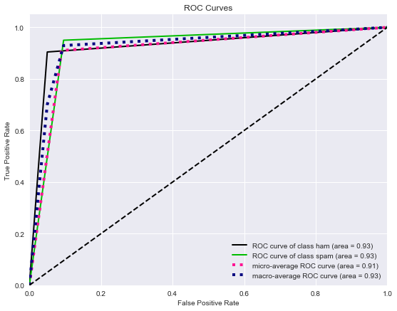

```python
plt.rcParams["figure.figsize"] = (9,7)
skplt.metrics.plot_roc_curve(labels_test,nb_predict_proba);
```

# Curiosity - Which words were highly associated with spam?

Referring to the scikit learn library for [Gaussian Naive Bayes](https://scikit-learn.org/stable/modules/generated/sklearn.naive_bayes.GaussianNB.html#sklearn.naive_bayes.GaussianNB) we will use its attributes to help us find the most spam-like words.

Percentage of (ham, spam)

```python
# the trailing underscore (_) means this was learned during fitting
model.class_prior_
```

```
array([ 0.86432161,  0.13567839])
```

Remember that our training dataset had 4179 entries, the counts of (ham, spam)

```python
model.class_count_
```

```
array([ 3612.,   567.])
```

Theta is the mean of each feature per class. So the first list is the mean of ham words and the second list is the mean of spam words.

```python
model.theta_
```

```
array([[ 0.        ,  0.        ,  0.00027685, ...,  0.        ,
         0.00193798,  0.00027685],
       [ 0.01410935,  0.03527337,  0.        , ...,  0.00176367,
         0.        ,  0.        ]])
```

```python
features = pd.DataFrame({'features':vecCount.get_feature_names(),'ham':model.theta_[0,:],'spam':model.theta_[1,:]}).set_index('features')
features.head()
```

| features | ham | spam |
| --- | --- | --- |
| 00 | 0.000000 | 0.014109 |
| 000 | 0.000000 | 0.035273 |
| 000pes | 0.000277 | 0.000000 |
| 008704050406 | 0.000000 | 0.003527 |
| 0121 | 0.000000 | 0.001764 |

From above we see that all unique 'words' are features. We will explore two methods for associating words with spam:

- highest mean value in spam column
- create a ratio of spam / ham

We first check the top 20 spam mean values.

```python
features.sort_values(['spam','ham'],ascending=[False,True]).head(20)
```

| features | ham | spam |
| --- | --- | --- |
| to | 0.332780 | 0.895944 |
| call | 0.046512 | 0.483245 |
| you | 0.408915 | 0.403880 |
| your | 0.086932 | 0.336861 |
| free | 0.012182 | 0.285714 |
| the | 0.239756 | 0.282187 |
| now | 0.060354 | 0.273369 |
| for | 0.105482 | 0.253968 |
| or | 0.051772 | 0.245150 |
| is | 0.160299 | 0.209877 |
| on | 0.079181 | 0.197531 |
| ur | 0.050664 | 0.195767 |
| txt | 0.002492 | 0.194004 |
| have | 0.093023 | 0.179894 |
| from | 0.032392 | 0.174603 |
| mobile | 0.003876 | 0.171076 |
| text | 0.014396 | 0.169312 |
| stop | 0.007475 | 0.162257 |
| and | 0.178571 | 0.156966 |
| with | 0.059247 | 0.153439 |

Here we find one of the limitations of using all default parameters for our model. 'to' is a very common english stop word with little meaning on it's own. Other stop word examples that made the list are 'the', 'for', 'and', 'or'. It is typical to remove such words from our features as they should not be adding any value to the model. Later we will remove stop words and re-assess our model.

Next if we create a ratio of spam / ham what will our top 20 spam words be? Since it's possible to get a divide by zero error we'll add a small number to all ham values so our ratio ranks properly.

Note the values in our spam ratio are somewhat arbitrary and we're only using them for ranking.

```python
# In order to avoid a divide by zero error we add a very small number to our ham column
features['spam_ratio'] = ((features.spam) / (features.ham+0.00001))
features.sort_values('spam_ratio',ascending=False).head(20)
```

| features | ham | spam | spam_ratio |
| --- | --- | --- | --- |
| claim | 0.0 | 0.142857 | 14285.714286 |
| prize | 0.0 | 0.130511 | 13051.146384 |
| uk | 0.0 | 0.104056 | 10405.643739 |
| 150p | 0.0 | 0.091711 | 9171.075838 |
| guaranteed | 0.0 | 0.074074 | 7407.407407 |
| 18 | 0.0 | 0.070547 | 7054.673721 |
| tone | 0.0 | 0.068783 | 6878.306878 |
| 16 | 0.0 | 0.067019 | 6701.940035 |
| cs | 0.0 | 0.063492 | 6349.206349 |
| 1000 | 0.0 | 0.061728 | 6172.839506 |
| 500 | 0.0 | 0.059965 | 5996.472663 |
| 150ppm | 0.0 | 0.052910 | 5291.005291 |
| awarded | 0.0 | 0.049383 | 4938.271605 |
| ringtone | 0.0 | 0.038801 | 3880.070547 |
| collection | 0.0 | 0.037037 | 3703.703704 |
| code | 0.0 | 0.037037 | 3703.703704 |
| 000 | 0.0 | 0.035273 | 3527.336861 |
| 5000 | 0.0 | 0.035273 | 3527.336861 |
| tones | 0.0 | 0.033510 | 3350.970018 |
| valid | 0.0 | 0.031746 | 3174.603175 |

Exploring the descriptive statistics for spam ratio. Mean is ≈98. The first (25%) and second (50%) quartiles are zero and the third (75%) quartile is ≈6 while the max value is ≈14,000. Visually this is asymptotic.

```python
features['spam_ratio'].describe()
```

```
count     7576.000000
mean        98.989596
std        441.272276
min          0.000000
25%          0.000000
50%          0.000000
75%          6.148294
max      14285.714286
Name: spam_ratio, dtype: float64
```

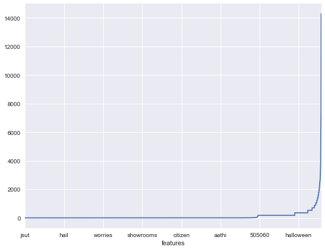

```python
features['spam_ratio'].sort_values().plot();
```

An idea for improvement: Since the vast majority of words have a spam ratio close to zero, we could create a new vocabulary (feature set) that contained words with spam ratio in the fourth quartile of values. Then we could conduct the same analysis for ham words and add to our features with words that have high ham ratio. All other words could be classified as noise and would not be included in our model.

## Re-testing the model and removing stop words

Returning to the stop words problem, we can use Count Vectorizer to remove stop words from a premade dictionary of words.

Let's test it.

```python
vecCountStop = CountVectorizer(stop_words='english')
features_train_dtm_stop = vecCountStop.fit_transform(features_train).toarray()
features_test_dtm_stop = vecCountStop.transform(features_test).toarray()
model2 = GaussianNB()
model2.fit(features_train_dtm_stop,labels_train)
predictions2 = model2.predict(features_test_dtm_stop)
```

```
GaussianNB(priors=None)
```

```python
acc2 = metrics.accuracy_score(labels_test, predictions2)
```

```python
f1score = metrics.f1_score(labels_test,predictions,average='weighted')
f1score2 = metrics.f1_score(labels_test,predictions2,average='weighted')
```

```python
nb_predict_proba2 = model2.predict_proba(features_test_dtm_stop)
roc_auc2 = metrics.roc_auc_score(np.array(labels_test.map({'ham':0,'spam':1})), nb_predict_proba2[:,1])
```

```python
# Comparing using stop
results = [['Metric','Including Stop Words','Removing Stop Words'],
      ['Accuracy',acc,acc2],
      ['F1 Score',f1score,f1score2],
      ['ROC AUC Score',roc_auc,roc_auc2]]
tbl.make_table(results)
tbl.set_global_style(align='center')
tbl.set_row_style(0, bold=True)
tbl.set_column_style(0, bold=True);
```

```python
tbl.render()
```

| **Metric** | **Including Stop Words** | **Removing Stop Words** |
| --- | --- | --- |
| **Accuracy** | 0.9103 | 0.8945 |
| **F1 Score** | 0.9185 | 0.9054 |
| **ROC AUC Score** | 0.9272 | 0.9181 |

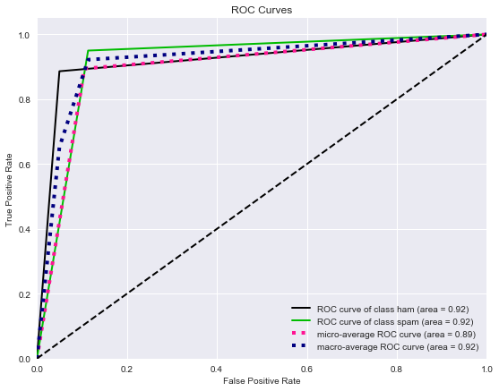

```python
skplt.metrics.plot_roc_curve(labels_test,nb_predict_proba2);
```

We find each metric is actually worse when removing stop words.

If we sort by mean spam value rather than spam ratio we see that stop words have been removed. However since removing stop words, our model has regressed. This may be due to some stop words being useful in identifying spam. For instance we see the word 'free' has the highest spam average now, where previous high ranking words like 'call' and 'now' have been removed.

In this result we would prefer our original model with stop words in our vocabulary. In reality we would explore different models and lots of parameter optimisation.

Features2 has stop words removed and Features leaves stop words in place

```python
features2 = pd.DataFrame({'features2':vecCountStop.get_feature_names(),'ham':model2.theta_[0,:],'spam':model2.theta_[1,:]}).set_index('features2')
features2['spam_ratio'] = (features2.spam) / (features2.ham+0.00001)
features2.sort_values('spam',ascending=False).head(20)
```

| features2 | ham | spam | spam_ratio |
| --- | --- | --- | --- |
| free | 0.012182 | 0.285714 | 23.435307 |
| ur | 0.050664 | 0.195767 | 3.863233 |
| txt | 0.002492 | 0.194004 | 77.548853 |
| mobile | 0.003876 | 0.171076 | 44.023984 |
| text | 0.014396 | 0.169312 | 11.752520 |
| stop | 0.007475 | 0.162257 | 21.677448 |
| claim | 0.000000 | 0.142857 | 14285.714286 |
| prize | 0.000000 | 0.130511 | 13051.146384 |
| reply | 0.009413 | 0.130511 | 13.850210 |
| www | 0.000554 | 0.118166 | 209.621641 |
| just | 0.061462 | 0.111111 | 1.807514 |
| cash | 0.003322 | 0.104056 | 31.226994 |
| uk | 0.000000 | 0.104056 | 10405.643739 |
| won | 0.004983 | 0.102293 | 20.485641 |
| send | 0.027962 | 0.093474 | 3.341673 |
| 150p | 0.000000 | 0.091711 | 9171.075838 |
| new | 0.013289 | 0.086420 | 6.498197 |
| urgent | 0.001661 | 0.084656 | 50.658002 |
| service | 0.000554 | 0.082892 | 147.048017 |
| contact | 0.003045 | 0.081129 | 26.552542 |

```python
features.sort_values('spam',ascending=False).head(20)
```

| features | ham | spam | spam_ratio |
| --- | --- | --- | --- |
| to | 0.332780 | 0.895944 | 2.692222 |
| call | 0.046512 | 0.483245 | 10.387537 |
| you | 0.408915 | 0.403880 | 0.987664 |
| your | 0.086932 | 0.336861 | 3.874525 |
| free | 0.012182 | 0.285714 | 23.435307 |
| the | 0.239756 | 0.282187 | 1.176925 |
| now | 0.060354 | 0.273369 | 4.528641 |
| for | 0.105482 | 0.253968 | 2.407471 |
| or | 0.051772 | 0.245150 | 4.734281 |
| is | 0.160299 | 0.209877 | 1.309200 |
| on | 0.079181 | 0.197531 | 2.494375 |
| ur | 0.050664 | 0.195767 | 3.863233 |
| txt | 0.002492 | 0.194004 | 77.548853 |
| have | 0.093023 | 0.179894 | 1.933655 |
| from | 0.032392 | 0.174603 | 5.388650 |
| mobile | 0.003876 | 0.171076 | 44.023984 |
| text | 0.014396 | 0.169312 | 11.752520 |
| stop | 0.007475 | 0.162257 | 21.677448 |
| and | 0.178571 | 0.156966 | 0.878963 |
| with | 0.059247 | 0.153439 | 2.589386 |

# Conclusion

In this notebook we learned how to use the Naive Bayes Algorithm to predict if messages are spam or ham (not spam).

Using the Guassian Naive Bayes model with no optimisation we have the following metrics for spam identification:

- Accuracy: 91%
- F1-Score: 0.92
- ROC-AUC-Score: 0.93

## Limitations of our analysis

- Only used one vectorization method and one model

## Future work that would improve our findings:

- Vectorization : try improved vectorization techniques such as TF IDF (term frequency-inverse document frequency) to remove common words.
- Modelling: try variations of Naive Bayes and other classification models
- Metrics: try use log-loss

```python
# Chris Said's script to hide a bunch of stuff
HTML('''
''')
```

# References

[Pandas official documentation (various)](https://pandas.pydata.org/pandas-docs/stable/index.html) 2017

[Seaborn official documentation (various)](https://seaborn.pydata.org/) 2017

[Highcharts Options Reference](https://api.highcharts.com/highcharts/) 2017

[Stack Overflow Questions (various for Pandas,Seaborn)](https://stackoverflow.com/questions) 2017

[Cross Validated - Stack Exchange Questions (various for Statistics)](https://stats.stackexchange.com/) 2017

[Univerty of Toronto - Crosstabulation with Nominal Variables](https://groups.chass.utoronto.ca/pol242/Labs/LM-3A/LM-3A_content.htm) 2017

[NYU - Quantitative Analysis Guide: Choose Statistical Test for 1 Dependent Variable](https://guides.nyu.edu/quant/choose_test_1DV) 2017

[UCLA - CHOOSING THE CORRECT STATISTICAL TEST IN SAS, STATA, SPSS AND R](https://stats.idre.ucla.edu/other/mult-pkg/whatstat/) 2017

# Appendix 1 - Metrics to Interpret Machine Learning Models

```python
# Typical Confusion Matrix
tcm = [['Actual (row) / Predicted (col)','Negative', 'Survived'],
      ['Negative','True Negative','False Positive'],
      ['Positive','False Negative','True Positive']]
tbl.make_table(tcm)
tbl.set_global_style(align='center')
tbl.set_row_style(0, bold=True)
tbl.set_column_style(0, bold=True);
```

```python
tbl.render()
```

| **Actual (row) / Predicted (col)** | **Negative** | **Survived** |
| --- | --- | --- |
| **Negative** | True Negative | False Positive |
| **Positive** | False Negative | True Positive |

TP = True Positive  
TN = True Negative  
FP = False Positive  
FN = False Negative

**Accuracy** $= \frac{TP+TN}{TP+FP+FN+TN}$

Accuracy is the number of correct predictions over total predictions. This can be a good metric if we have symmetrical data, that is, equal amount of positive and negative values in the dataset. If we have asymmetrical data we may have a model that returns high accuracy, but fail to predict any of the minority case.

**Precision** $= \frac{TP}{TP+FP}$

Precision aka Specificity is the ratio of correct positive predictions over the total positive predictions. How few False Positives did we find?  
Precision = 1 means no False Positives found. We predicted positive scenarios perfectly.  
Pricision = 0 means all False Positives were found. We predicted no positive scenarios.

**Recall** $= \frac{TP}{TP+FN}$

Recall aka Sensitivity is the ratio of correct positive predictions over the total actual positive values. How few False Negatives did we find?  
Recall = 1 means no False Negatives found. We never predicted a Positive value to be Negative.  
Recall = 0 means all False Negatives were found. We predicted all Positive values to be Negative.

There is a natural trade off between precision and recall. If we wanted perfect recall, we can simply predict all data is Positive. We would have many False Positives (FP) but no False Negatives (FN) hence Recall = 1. Knowing this we can use the F1-Score as a balanced metric.

**F1-Score** $= \frac{2\times(Recall\times Precision)}{Recall + Precision}$

F1-Score is the weighted average of Precision and Recall.

python jupyter notebooks pandas machine learning sklearn naive bayes